EDA David Martin 4/13/2021

[Download materials](https://github.com/HSL-Data/BIMS_8382_Web/blob/master/public/zips/eda.zip?raw=true)

# Today’s Class

For Today’s class we are going to be focusing on useful options within Rmarkdown and additional functionality within ggplot.

# RMarkdown Options

When setting options for your RMarkdown file you can either set them globally at the top of your code or you can set them locally within each code chunk.

# Getting Started

We are going to be using a bunch of packages today, so let us make sure that we install new packages and load up all of the packages we need for today.

```r
# Load up the tidyverse
library(tidyverse)

#install.packages("NHANES")
library(NHANES)
library(skimr)
library(ggthemes)

#install.packages("gapminder")
library(gapminder)

#install.packages("ggmosaic")
library(ggmosaic)

#install.packages("ggrepel")
library(ggrepel)

#install.packages("ggpubr")
library(ggpubr)
```

Let’s go ahead and read in the data. We are going to take half of the data and then filter for only those greater than 18.

```r
set.seed(123)
nh <- NHANES  %>% sample_frac(.5) %>% filter(Age >= 18)
skim(nh)
```

Data summary

| Name | nh |
| --- | --- |
| Number of rows | 3731 |
| Number of columns | 76 |
| _______________________ |  |
| Column type frequency: |  |
| factor | 31 |
| numeric | 45 |
| ________________________ |  |
| Group variables | None |

**Variable type: factor**

| skim_variable | n_missing | complete_rate | ordered | n_unique | top_counts |
| --- | --- | --- | --- | --- | --- |
| SurveyYr | 0 | 1.00 | FALSE | 2 | 200: 1916, 201: 1815 |
| Gender | 0 | 1.00 | FALSE | 2 | mal: 1870, fem: 1861 |
| AgeDecade | 167 | 0.96 | FALSE | 7 | 40: 712, 30: 675, 20: 648, 50: 635 |
| Race1 | 0 | 1.00 | FALSE | 5 | Whi: 2468, Bla: 435, Mex: 313, Oth: 295 |
| Race3 | 1916 | 0.49 | FALSE | 6 | Whi: 1206, Bla: 201, Mex: 139, His: 117 |
| Education | 132 | 0.96 | FALSE | 5 | Som: 1083, Col: 1066, Hig: 765, 9 -: 452 |
| MaritalStatus | 128 | 0.97 | FALSE | 6 | Mar: 1981, Nev: 673, Div: 333, Liv: 288 |
| HHIncome | 334 | 0.91 | FALSE | 12 | mor: 837, 750: 410, 250: 344, 350: 312 |
| HomeOwn | 23 | 0.99 | FALSE | 3 | Own: 2430, Ren: 1188, Oth: 90 |
| Work | 0 | 1.00 | FALSE | 3 | Wor: 2280, Not: 1293, Loo: 158 |
| BMICatUnder20yrs | 3675 | 0.02 | FALSE | 4 | Nor: 31, Obe: 12, Ove: 7, Und: 6 |
| BMI_WHO | 54 | 0.99 | FALSE | 4 | 30.: 1283, 25.: 1227, 18.: 1101, 12.: 66 |
| Diabetes | 1 | 1.00 | FALSE | 2 | No: 3374, Yes: 356 |
| HealthGen | 387 | 0.90 | FALSE | 5 | Goo: 1303, Vgo: 1092, Fai: 465, Exc: 389 |
| LittleInterest | 408 | 0.89 | FALSE | 3 | Non: 2551, Sev: 560, Mos: 212 |
| Depressed | 406 | 0.89 | FALSE | 3 | Non: 2631, Sev: 497, Mos: 197 |
| SleepTrouble | 0 | 1.00 | FALSE | 2 | No: 2778, Yes: 953 |
| PhysActive | 0 | 1.00 | FALSE | 2 | Yes: 1942, No: 1789 |
| TVHrsDay | 1916 | 0.49 | FALSE | 7 | 2_h: 434, 3_h: 320, 1_h: 308, 0_t: 250 |
| CompHrsDay | 1916 | 0.49 | FALSE | 7 | 0_t: 498, 0_h: 423, 1_h: 393, 2_h: 224 |
| Alcohol12PlusYr | 458 | 0.88 | FALSE | 2 | Yes: 2564, No: 709 |
| SmokeNow | 2112 | 0.43 | FALSE | 2 | No: 886, Yes: 733 |
| Smoke100 | 126 | 0.97 | FALSE | 2 | No: 1986, Yes: 1619 |
| Smoke100n | 126 | 0.97 | FALSE | 2 | Non: 1986, Smo: 1619 |
| Marijuana | 1290 | 0.65 | FALSE | 2 | Yes: 1430, No: 1011 |
| RegularMarij | 1290 | 0.65 | FALSE | 2 | No: 1767, Yes: 674 |
| HardDrugs | 864 | 0.77 | FALSE | 2 | No: 2357, Yes: 510 |
| SexEver | 864 | 0.77 | FALSE | 2 | Yes: 2756, No: 111 |
| SameSex | 865 | 0.77 | FALSE | 2 | No: 2668, Yes: 198 |
| SexOrientation | 1340 | 0.64 | FALSE | 3 | Het: 2289, Bis: 54, Hom: 48 |
| PregnantNow | 2901 | 0.22 | FALSE | 3 | No: 771, Yes: 35, Unk: 24 |

**Variable type: numeric**

| skim_variable | n_missing | complete_rate | mean | sd | p0 | p25 | p50 | p75 | p100 | hist |
| --- | --- | --- | --- | --- | --- | --- | --- | --- | --- | --- |
| ID | 0 | 1.00 | 61796.01 | 5907.07 | 51624.00 | 56675.00 | 61830.00 | 66926.50 | 71915.00 | ▇▇▇▇▇ |
| Age | 0 | 1.00 | 46.40 | 17.40 | 18.00 | 32.00 | 45.00 | 60.00 | 80.00 | ▇▇▇▆▅ |
| AgeMonths | 1898 | 0.49 | 538.82 | 195.08 | 216.00 | 370.00 | 526.00 | 682.00 | 959.00 | ▇▇▇▆▃ |
| HHIncomeMid | 334 | 0.91 | 57609.66 | 33241.75 | 2500.00 | 30000.00 | 50000.00 | 87500.00 | 100000.00 | ▃▆▃▁▇ |
| Poverty | 292 | 0.92 | 2.93 | 1.69 | 0.00 | 1.31 | 2.91 | 5.00 | 5.00 | ▃▅▃▃▇ |
| HomeRooms | 28 | 0.99 | 6.11 | 2.25 | 1.00 | 4.00 | 6.00 | 7.00 | 13.00 | ▂▆▇▂▁ |
| Weight | 32 | 0.99 | 82.04 | 21.45 | 37.00 | 66.60 | 79.30 | 93.55 | 230.70 | ▇▇▁▁▁ |
| Length | 3731 | 0.00 | NaN | NA | NA | NA | NA | NA | NA |  |
| HeadCirc | 3731 | 0.00 | NaN | NA | NA | NA | NA | NA | NA |  |
| Height | 30 | 0.99 | 168.95 | 10.07 | 134.50 | 161.60 | 168.90 | 176.40 | 200.40 | ▁▃▇▆▁ |
| BMI | 35 | 0.99 | 28.64 | 6.68 | 15.22 | 23.93 | 27.60 | 32.10 | 81.25 | ▇▆▁▁▁ |
| Pulse | 127 | 0.97 | 72.43 | 11.84 | 40.00 | 64.00 | 72.00 | 80.00 | 136.00 | ▂▇▃▁▁ |
| BPSysAve | 132 | 0.96 | 120.36 | 17.01 | 80.00 | 109.00 | 118.00 | 129.00 | 217.00 | ▃▇▂▁▁ |
| BPDiaAve | 132 | 0.96 | 69.62 | 12.54 | 0.00 | 63.00 | 70.00 | 77.00 | 116.00 | ▁▁▇▇▁ |
| BPSys1 | 277 | 0.93 | 121.41 | 17.14 | 72.00 | 110.00 | 118.00 | 130.00 | 220.00 | ▁▇▂▁▁ |
| BPDia1 | 277 | 0.93 | 70.38 | 12.16 | 0.00 | 64.00 | 70.00 | 78.00 | 118.00 | ▁▁▇▇▁ |
| BPSys2 | 213 | 0.94 | 120.58 | 17.25 | 76.00 | 110.00 | 118.00 | 128.00 | 220.00 | ▂▇▂▁▁ |
| BPDia2 | 213 | 0.94 | 69.79 | 12.68 | 0.00 | 64.00 | 70.00 | 78.00 | 118.00 | ▁▁▇▇▁ |
| BPSys3 | 210 | 0.94 | 120.05 | 17.00 | 76.00 | 108.00 | 118.00 | 128.00 | 214.00 | ▂▇▂▁▁ |
| BPDia3 | 210 | 0.94 | 69.36 | 13.10 | 0.00 | 62.00 | 70.00 | 78.00 | 116.00 | ▁▁▆▇▁ |
| Testosterone | 2035 | 0.45 | 213.55 | 222.40 | 0.25 | 20.45 | 119.71 | 372.92 | 1244.73 | ▇▅▂▁▁ |
| DirectChol | 187 | 0.95 | 1.37 | 0.42 | 0.39 | 1.06 | 1.29 | 1.60 | 4.03 | ▅▇▂▁▁ |
| TotChol | 187 | 0.95 | 5.03 | 1.05 | 1.53 | 4.27 | 4.97 | 5.66 | 10.29 | ▁▇▇▁▁ |
| UrineVol1 | 44 | 0.99 | 122.90 | 92.15 | 0.00 | 52.00 | 96.00 | 170.00 | 510.00 | ▇▅▂▁▁ |
| UrineFlow1 | 223 | 0.94 | 1.04 | 1.00 | 0.00 | 0.43 | 0.75 | 1.30 | 17.17 | ▇▁▁▁▁ |
| UrineVol2 | 3168 | 0.15 | 123.44 | 92.06 | 0.00 | 53.00 | 100.00 | 171.00 | 409.00 | ▇▆▃▂▁ |
| UrineFlow2 | 3170 | 0.15 | 1.12 | 1.00 | 0.00 | 0.50 | 0.74 | 1.41 | 5.47 | ▇▂▁▁▁ |
| DiabetesAge | 3432 | 0.08 | 49.13 | 14.36 | 3.00 | 40.00 | 49.00 | 59.00 | 80.00 | ▁▂▇▇▃ |
| DaysPhysHlthBad | 391 | 0.90 | 3.54 | 7.68 | 0.00 | 0.00 | 0.00 | 3.00 | 30.00 | ▇▁▁▁▁ |
| DaysMentHlthBad | 391 | 0.90 | 4.13 | 7.88 | 0.00 | 0.00 | 0.00 | 4.00 | 30.00 | ▇▁▁▁▁ |
| nPregnancies | 2455 | 0.34 | 3.02 | 1.85 | 1.00 | 2.00 | 3.00 | 4.00 | 32.00 | ▇▁▁▁▁ |
| nBabies | 2547 | 0.32 | 2.46 | 1.30 | 0.00 | 2.00 | 2.00 | 3.00 | 11.00 | ▇▅▁▁▁ |
| Age1stBaby | 2805 | 0.25 | 22.68 | 4.73 | 14.00 | 19.00 | 22.00 | 26.00 | 39.00 | ▆▇▅▂▁ |
| SleepHrsNight | 6 | 1.00 | 6.90 | 1.32 | 2.00 | 6.00 | 7.00 | 8.00 | 12.00 | ▁▅▇▁▁ |
| PhysActiveDays | 1865 | 0.50 | 3.69 | 1.85 | 1.00 | 2.00 | 3.00 | 5.00 | 7.00 | ▇▆▃▅▅ |
| TVHrsDayChild | 3731 | 0.00 | NaN | NA | NA | NA | NA | NA | NA |  |
| CompHrsDayChild | 3731 | 0.00 | NaN | NA | NA | NA | NA | NA | NA |  |
| AlcoholDay | 1324 | 0.65 | 2.90 | 2.80 | 1.00 | 1.00 | 2.00 | 3.00 | 36.00 | ▇▁▁▁▁ |
| AlcoholYear | 786 | 0.79 | 71.90 | 101.62 | 0.00 | 2.00 | 24.00 | 104.00 | 364.00 | ▇▁▁▁▁ |
| SmokeAge | 2179 | 0.42 | 17.66 | 5.22 | 6.00 | 15.00 | 17.00 | 19.00 | 72.00 | ▇▂▁▁▁ |
| AgeFirstMarij | 2302 | 0.38 | 17.02 | 4.04 | 6.00 | 15.00 | 16.00 | 18.00 | 48.00 | ▂▇▁▁▁ |
| AgeRegMarij | 3057 | 0.18 | 17.69 | 4.95 | 8.00 | 15.00 | 17.00 | 19.00 | 46.00 | ▅▇▁▁▁ |
| SexAge | 977 | 0.74 | 17.40 | 3.72 | 9.00 | 15.00 | 17.00 | 19.00 | 50.00 | ▇▅▁▁▁ |
| SexNumPartnLife | 883 | 0.76 | 15.77 | 65.53 | 0.00 | 2.00 | 5.00 | 12.00 | 2000.00 | ▇▁▁▁▁ |
| SexNumPartYear | 1293 | 0.65 | 1.35 | 2.88 | 0.00 | 1.00 | 1.00 | 1.00 | 69.00 | ▇▁▁▁▁ |

Using the `results = "hide"` option, we can hide the results that would normally be outputted into the markdown document.

```r
#Hiding Results
skim(nh)
```

Also notice the use of the `` (accent marks) to highlight r code within your prose. This is also a good way of highlighting specific results.

```r
BMI <- mean(nh$BMI, na.rm = TRUE)
BMI
```

```
## [1] 28.64197
```

The mean BMI for this dataset is 28.64. Using `r` allows you to insert a code chunk inline. This would allow you to simply update your code to update your results. You will not need to hard code in actual results.

## Back to some plotting

We are going to continue with our investigation into the NHANES dataset by looking at Race and Testosterone levels among male patients.

Here we can also see some options for the layout of plots within R Markdown. `fig.align` sets the location of the plot (left, right, center), `fig.height` sets the height of the figure, and `fig.width` sets the width.

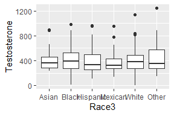

```r
 nh  %>%
  filter(Gender == "male") %>%
  drop_na(Race3, Testosterone) %>%
  ggplot(aes(Race3, Testosterone)) +
  geom_boxplot()
```

```r
 nh %>%
  filter(Gender == "male") %>%
  drop_na(Race3) %>%
  group_by(Race3) %>%
  dplyr::summarize(median_Testosterone = median(Testosterone, na.rm = TRUE)) %>%
  arrange(median_Testosterone)
```

```
## # A tibble: 6 x 2
##   Race3    median_Testosterone
##   <fct>                  <dbl>
## 1 Mexican                 319.
## 2 Hispanic                331.
## 3 Other                   350.
## 4 Asian                   361.
## 5 White                   376.
## 6 Black                   390.
```

Most plots are much more effective if the axes are sorted in a more meaningful, informative way. To do that, we’ll have to go back to our basic build of the plot again and use the `reorder()` function in our original aesthetic mapping.

`reorder()` takes the first variable, which is some categorical variable, and ordering it by the level of the mean of the second variable, which is a continuous variable.

It looks like this.

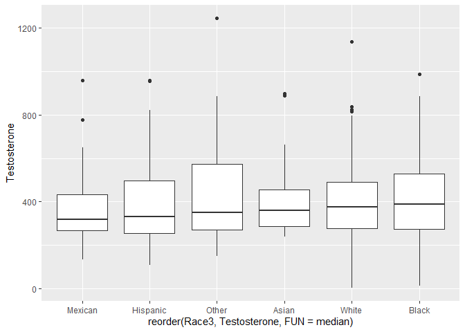

```r
# ?reorder
p<- nh  %>%
  filter(Gender == "male") %>%
  drop_na(Race3, Testosterone) %>%
  ggplot(aes(reorder(Race3, Testosterone, FUN = median), y = Testosterone))

p + geom_boxplot()
```

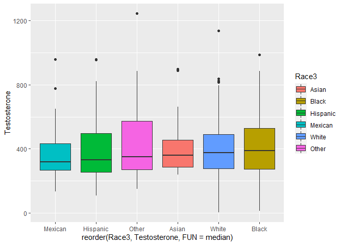

```r
p + geom_boxplot(aes(fill = Race3))
```

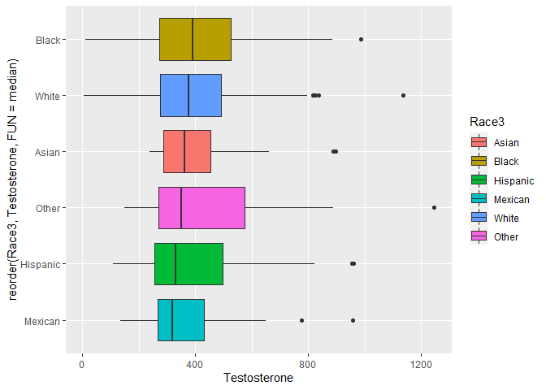

```r
p + geom_boxplot(aes(fill = Race3)) + coord_flip()
```

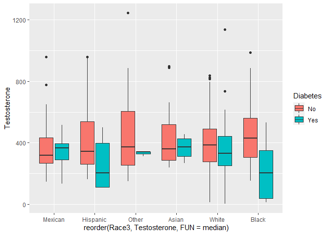

```r
#If you wanted to break down by another factor
nh$Diabetes <- factor(nh$Diabetes, levels = c("Yes", "No"))
p + geom_boxplot(aes(fill = Diabetes))
```

## Alternative to a box plot

Box plots are used quite often, but they are not always the best visualization for the job. They illustrate the median and IQR of the data, while most often we are worried about the mean and the spread of the data.

The following plot shows the spread of the data, provides summary information for the data, and also keeps the raw data.

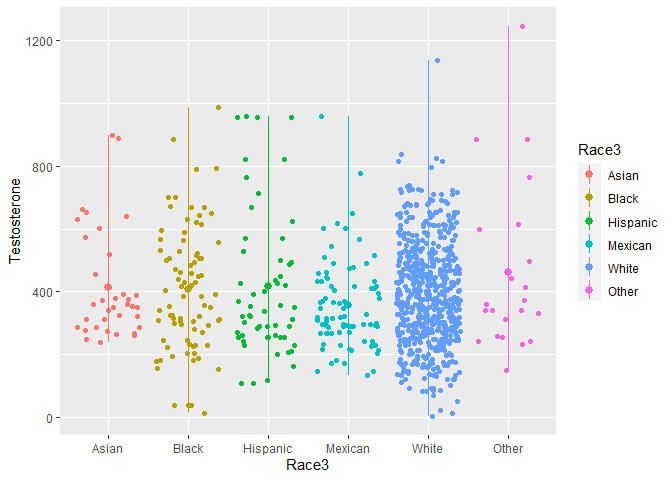

```r
# plot results *A better way
nh %>%
  drop_na(Race3) %>%
  filter(Gender == "male") %>%
  group_by(Race3) %>%
  summarize(min = min(Testosterone, na.rm  = TRUE),
            max = max(Testosterone, na.rm = TRUE),
            Testosterone = mean(Testosterone, na.rm = TRUE)) %>%
ggplot(aes(Race3, Testosterone, color = Race3)) +
  geom_pointrange(aes(ymin = min, ymax = max)) +
  geom_jitter(data = filter(nh, Gender == "male" & !is.na(Race3)), aes(Race3, Testosterone))
```

Adding error bars to bar charts is also a better way of showing off your data.

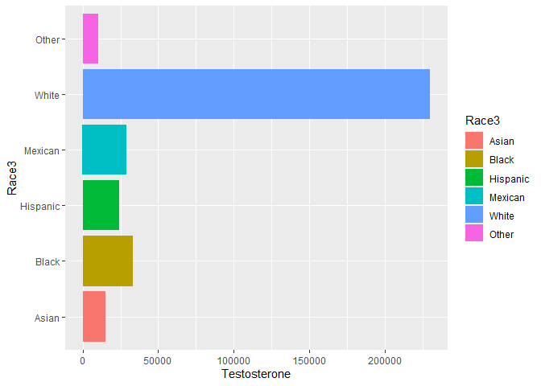

```r
nh %>%  drop_na(Race3) %>%
  filter(Gender == "male") %>%
ggplot(aes(Testosterone, Race3, fill = Race3)) + geom_col()
```

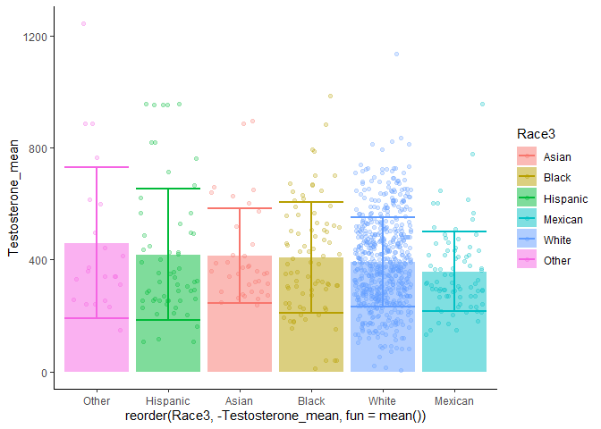

```r
nh %>%  drop_na(Race3, Testosterone) %>%
  filter(Gender == "male") %>%
  group_by(Race3) %>%
  summarize(Testosterone_mean = mean(Testosterone, na.rm = TRUE),
            sd = sd(Testosterone, na.rm = TRUE)) %>%
  mutate(lowerBound = Testosterone_mean - sd,
         upperBound = Testosterone_mean + sd) %>%
ggplot(aes(Testosterone_mean, reorder(Race3, -Testosterone_mean, fun = mean()), fill = Race3)) + geom_col(alpha = .5) + coord_flip() + geom_errorbar(aes(xmin = lowerBound, xmax = upperBound, color = Race3), size = 1) + geom_jitter(data = filter(nh, Gender == "male" & !is.na(Race3)), aes(Testosterone, Race3, color = Race3), alpha = .25)  +
theme_classic()
```

Possibly a better option

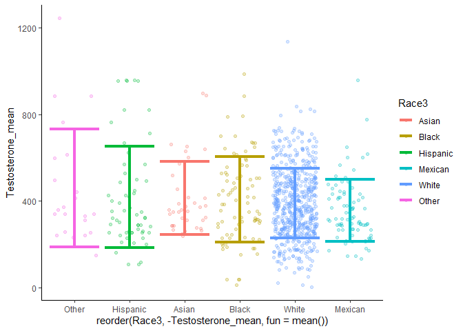

```r
nh %>%  drop_na(Race3, Testosterone) %>%
  filter(Gender == "male") %>%
  group_by(Race3) %>%
  summarize(Testosterone_mean = mean(Testosterone, na.rm = TRUE),
            sd = sd(Testosterone, na.rm = TRUE)) %>%
  mutate(lowerBound = Testosterone_mean - sd,
         upperBound = Testosterone_mean + sd) %>%
ggplot(aes(Testosterone_mean, reorder(Race3, -Testosterone_mean, fun = mean()), fill = Race3)) + coord_flip() + geom_errorbar(aes(xmin = lowerBound, xmax = upperBound, color = Race3), size = 1.5) + geom_jitter(data = filter(nh, Gender == "male" & !is.na(Race3)), aes(Testosterone, Race3, color = Race3), alpha = .25)  +
theme_classic()
```

# Saving plots

There are a few ways to save ggplots. The quickest way, that works in an interactive session, is to use the `ggsave()` function. You give it a file name and by default it saves the last plot that was printed to the screen.

```r
ggsave(file="Testosterone.png")
```

Where did it go? You will see that it went directly into your project folder. Typically, I would prefer to have a directory structure that has my code, images, results, etc. all separated out.

In a script, the best way to do it is to pass `ggsave()` the object containing the plot that is meant to be saved. We can also adjust things like the width, height, and resolution. `ggsave()` also recognizes the name of the file extension and saves the appropriate kind of file. Let’s save a PDF.

```r
# I am first going to create a single column of graphs so that each graph in the facet wrap gets its own row
pfinal <- p +
  geom_boxplot(aes(fill = Race3)) +
  facet_wrap(~Diabetes, ncol = 1)
pfinal

ggsave(pfinal, file="Diabetes.pdf", width=7, height=16)
```

[output not shown]

## Plotting Multiple Datasets

Oftentimes you may need to combine datasets into one plot, which we did with the Alternative to Box Plot portion. This can be done by resetting the data option within the `geom_` functions.

```r
nh %>%
  count(Race3)
```

```
## # A tibble: 7 x 2
##   Race3        n
##   <fct>    <int>
## 1 Asian      108
## 2 Black      201
## 3 Hispanic   117
## 4 Mexican    139
## 5 White     1206
## 6 Other       44
## 7 <NA>      1916
```

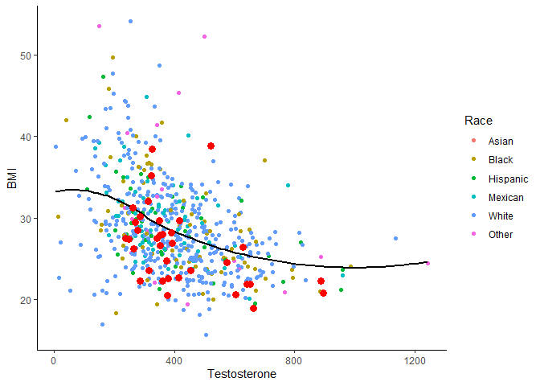

```r
# We want to simply point out the Asian males in the upcoming plot
Race <- nh %>%
  filter(Race3 == "Asian" & Gender == "male")

#ggplot will use the nh dataset for the first two geoms, but then will use the Race dataset for the second geom_point.

nh %>%
  drop_na(Race3) %>%
  filter(Gender == "male") %>%
ggplot() +
  geom_point(aes(x = Testosterone, y = BMI, color = factor(Race3))) +
  geom_smooth(aes(x = Testosterone, y = BMI),
              color = "black", se = FALSE) +
  geom_point(data = Race,
            aes(x = Testosterone, y = BMI),
            color = "red", size = 3) +
  theme_classic() + labs(color = "Race", y = "BMI", x = "Testosterone")
```

# Extensions to ggplot2

The website below shows a whole bunch of different ways that you can use ggplot:

Extensions to ggplot2 (https://exts.ggplot2.tidyverse.org/gallery/)

One example is the `ggmosaic` package, which allows you to plot two categorical variables against each other.

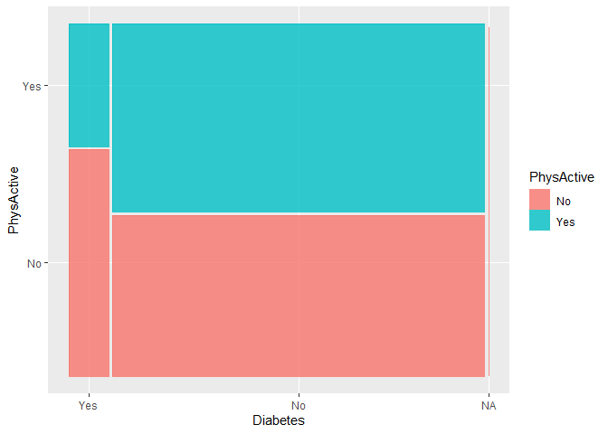

```r
ggplot(nh) + geom_mosaic(aes(x = product(Diabetes), fill=PhysActive))
```

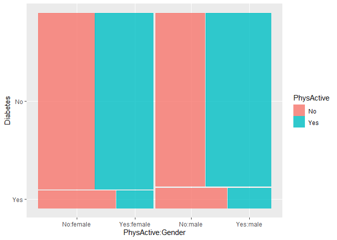

```r
ggplot(nh) + geom_mosaic(aes(x = product(Diabetes, Gender), fill=PhysActive), na.rm = TRUE)
```

# Adding Equations to your plot

One thing we might want to do with our plots is to add the equations and R values. This can be done utilizing functions from the `ggpub` package.

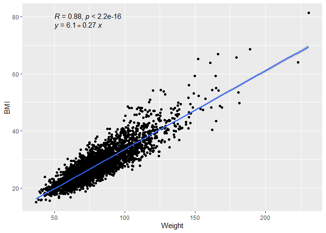

```r
ggplot(nh, aes(x = Weight, y = BMI)) +
  geom_point() +
  geom_smooth(method = "lm") +
  stat_cor(label.x = 50, label.y = 80) +
  stat_regline_equation(label.x = 50, label.y = 77)
```

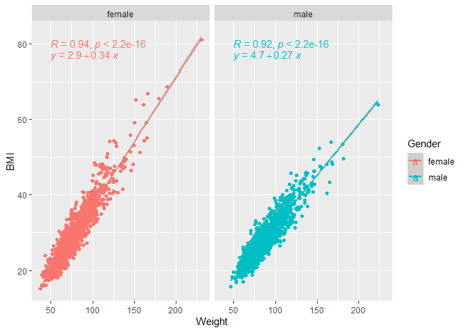

```r
ggplot(nh, aes(x = Weight, y = BMI, color = Gender)) +
  geom_point() +
  geom_smooth(method = "lm") +
  stat_cor(label.x = 50, label.y = 80) +
  stat_regline_equation(label.x = 50, label.y = 77)  +
  facet_wrap(~Gender)
```

# Paired data

Sometimes you want to look at your data before and after something or between two different time frames. We are going to do that within the NHANES dataset. However, the NHANES dataset only has the SurveyYr in a strange fashion. We need to create a more usable year variable, which can be done in a couple of ways.

One way we are going to do this is using the `str_sub` function. The `str_sub` function returns a portion of a string variable.

```r
str_sub(string = "Test This Out", start = 4, end = 10)
```

```
## [1] "t This "
```

```r
str_sub(string = nh$SurveyYr, start = 1, end = 4)
```

[output not shown]

[output cut: 359 more lines]

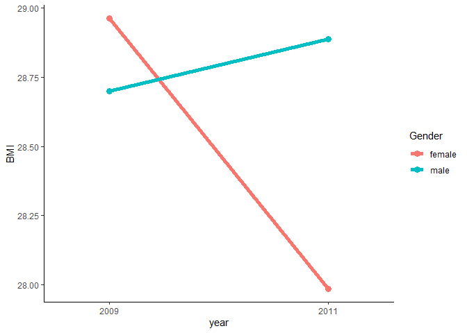

```r
nh$year <- str_sub(string = nh$SurveyYr, start = 1, end = 4)
nh$year <- as.numeric(nh$year)

nh %>% group_by(year, Gender) %>%
  summarize(BMI = mean(BMI, na.rm = TRUE)) %>%
ggplot(aes(x = year, y = BMI, color = Gender)) +
  geom_point(size = 3) +
  geom_line(size = 2) +
  theme_classic() +
  scale_x_discrete(limits = c(2009, 2011))
```

The `str_replace` function and `separate` functions would also be helpful, but we will be talking about those next class.

# Longitudinal Data

Finally, we can look at data over time utilizing `geom_line()` and `geom_point()` functions. We will be covering a more complicated process during the next class.

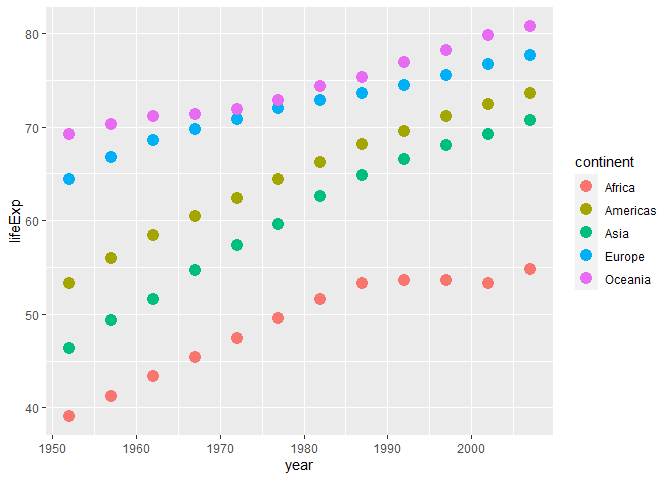

```r
gm <- gapminder

gm %>%
  group_by(year, continent) %>%
  summarize(lifeExp = mean(lifeExp, na.rm = TRUE)) %>%
  ggplot(aes(year, lifeExp, color = continent)) +
  geom_point(size = 4)
```

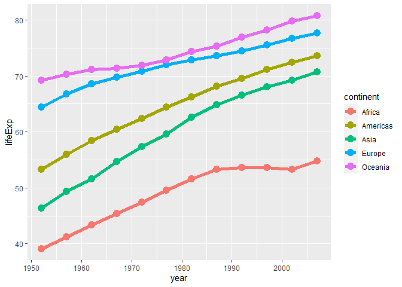

```r
p <- gm %>%
  group_by(year, continent) %>%
  summarize(lifeExp = mean(lifeExp, na.rm = TRUE)) %>%
  ggplot(aes(year, lifeExp, color = continent)) +
  geom_line(size = 2) +
  geom_point(size = 4)
p
```

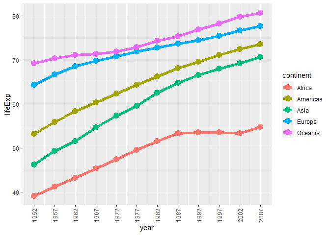

```r
p + scale_x_continuous(breaks = seq(from = 1952, to = 2007, by = 5)) + theme(axis.text.x = element_text(angle = 90, vjust = 0.5, hjust=1))
```

If you want to create a more aesthetically appealing graph, you can remove the legend and add labels to your graphs. Adding labels to our graphs involves the use of a function from the `ggrepel` package.

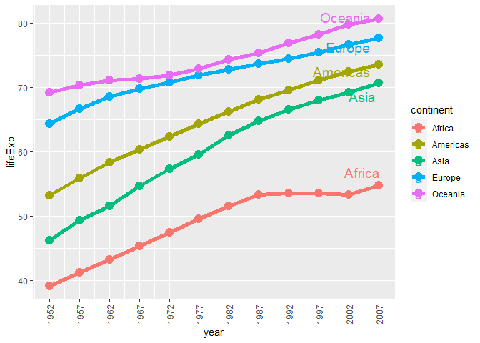

```r
gm %>%
  group_by(year, continent) %>%
  summarize(lifeExp = mean(lifeExp, na.rm = TRUE)) %>%
  mutate(label = if_else(year == 2007, as.character(continent), NA_character_)) %>%
  ggplot(aes(year, lifeExp, color = continent)) +
  geom_line(size = 2) +
  geom_point(size = 4) +
  scale_x_continuous(breaks = seq(from = 1952, to = 2007, by = 5)) +
  theme(axis.text.x = element_text(angle = 90, vjust = 0.5, hjust=1)) + geom_label_repel(aes(label = label, group = continent), nudge_x = 1, na.rm = TRUE, label.size = NA, fill = NA, size = 5)
```

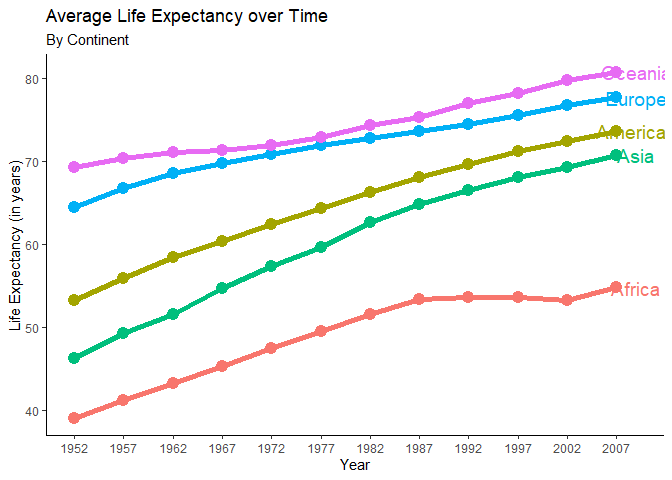

```r
# Adding some extra aesthetics
gm %>%
  group_by(year, continent) %>%
  summarize(lifeExp = mean(lifeExp, na.rm = TRUE)) %>%
  mutate(label = if_else(year == 2007, as.character(continent), NA_character_)) %>%
  ggplot(aes(year, lifeExp, color = continent)) +
  geom_line(size = 2) +
  geom_point(size = 4) +
  scale_x_continuous(breaks = seq(from = 1952, to = 2007, by = 5)) +
  geom_text(aes(label = label, x = year + 2, color = continent), size = 5) +
  guides(color = FALSE) +
  theme_classic() +
  labs(x = "Year", y = "Life Expectancy (in years)", title = "Average Life Expectancy over Time", subtitle = "By Continent")
```

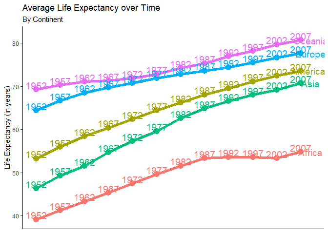

```r
# Data labels for each year.
gm %>%
  group_by(year, continent) %>%
  summarize(lifeExp = mean(lifeExp, na.rm = TRUE)) %>%
  mutate(label = if_else(year == 2007, as.character(continent), NA_character_)) %>%
  ggplot(aes(year, lifeExp, color = continent)) +
  geom_line(size = 2) +
  geom_point(size = 4) +
  scale_x_continuous(breaks = seq(from = 1952, to = 2007, by = 5)) +
  geom_text(aes(label = label, x = year + 2, color = continent), size = 5) +
  geom_text(aes(label = year,  color = continent), size = 5, nudge_y = 1) +
  guides(color = FALSE) +
  theme_classic() +   theme(axis.title.x = element_blank(), axis.ticks.x = element_blank(), axis.text.x = element_blank()) +
  labs(x = "Year", y = "Life Expectancy (in years)", title = "Average Life Expectancy over Time", subtitle = "By Continent")
```

# Next Time in 8382

In our next class, we are going to be working with data that needs to be transformed and reshaped in order to be able to be analyzed and visualized.

This will involve merging datasets, reshaping datasets, and other data wrangling tasks.

```r
mobile <- readr::read_csv('https://raw.githubusercontent.com/rfordatascience/tidytuesday/master/data/2020/2020-11-10/mobile.csv') %>%
  select(entity, code, year, mobile_subs)

phones <- readr::read_csv('https://raw.githubusercontent.com/rfordatascience/tidytuesday/master/data/2020/2020-11-10/landline.csv') %>%
  inner_join(mobile, by = c("entity", "code", "year")) %>%
  select(entity, year, continent, landline_subs, mobile_subs, everything()) %>%
filter(total_pop > 20000000 & continent != "Oceania")

table(phones$year)
```

```
##
## 1990 1991 1992 1993 1994 1995 1996 1997 1998 1999 2000 2001 2002 2003 2004 2005
##   42   43   43   44   44   47   47   47   47   49   49   49   50   50   50   52
## 2006 2007 2008 2009 2010 2011 2012 2013 2014 2015 2016 2017
##   53   53   54   57   58   58   58   57   56   57   56   54
```

```r
table(phones$year_cat)
```

```
## < table of extent 0 >
```

```r
skim(phones)
```

Data summary

| Name | phones |
| --- | --- |
| Number of rows | 1424 |
| Number of columns | 8 |
| _______________________ |  |
| Column type frequency: |  |
| character | 3 |
| numeric | 5 |
| ________________________ |  |
| Group variables | None |

**Variable type: character**

| skim_variable | n_missing | complete_rate | min | max | empty | n_unique | whitespace |
| --- | --- | --- | --- | --- | --- | --- | --- |
| entity | 0 | 1 | 4 | 28 | 0 | 59 | 0 |
| continent | 0 | 1 | 4 | 8 | 0 | 4 | 0 |
| code | 0 | 1 | 3 | 3 | 0 | 59 | 0 |

**Variable type: numeric**

| skim_variable | n_missing | complete_rate | mean | sd | p0 | p25 | p50 | p75 | p100 | hist |
| --- | --- | --- | --- | --- | --- | --- | --- | --- | --- | --- |
| year | 0 | 1.00 | 2004.26 | 7.99 | 1.9900e+03 | 1997.00 | 2005.00 | 2011.00 | 2.017000e+03 | ▆▆▇▆▇ |
| landline_subs | 37 | 0.97 | 16.16 | 18.57 | 0.0000e+00 | 1.42 | 8.52 | 22.83 | 6.827000e+01 | ▇▂▁▁▁ |
| mobile_subs | 33 | 0.98 | 45.95 | 48.36 | 0.0000e+00 | 0.72 | 28.94 | 84.77 | 1.912300e+02 | ▇▂▂▂▁ |
| total_pop | 0 | 1.00 | 111154082.65 | 231970780.63 | 2.0002e+07 | 28475500.00 | 47035000.00 | 82391000.00 | 1.421022e+09 | ▇▁▁▁▁ |
| gdp_per_cap | 63 | 0.96 | 13274.11 | 12881.00 | 5.1479e+02 | 3015.70 | 9251.18 | 17386.99 | 5.422545e+04 | ▇▃▁▂▁ |

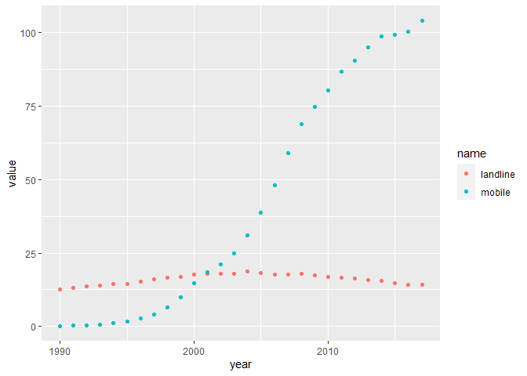

```r
phones %>%
  select(entity, year, landline_subs, mobile_subs) %>%
  pivot_longer(cols = c("landline_subs", "mobile_subs")) %>%
  mutate(name = str_replace(name, "_subs","")) %>%
  group_by(year, name) %>%
  summarize(value = mean(value, na.rm = TRUE)) %>%
  ggplot(aes(year, value, color = name)) +
  geom_point()
```

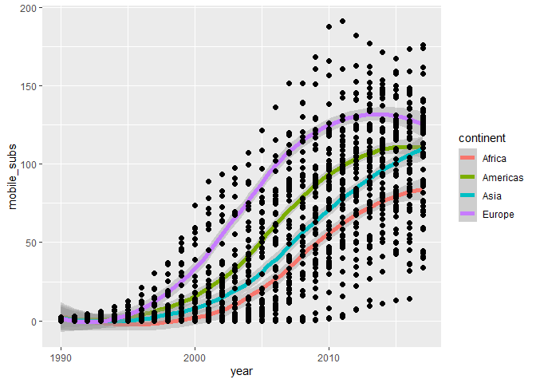

```r
phones %>%
  ggplot(aes(year, mobile_subs)) +
  geom_smooth(aes(color = continent), size = 2) + geom_point(size = 2)
```

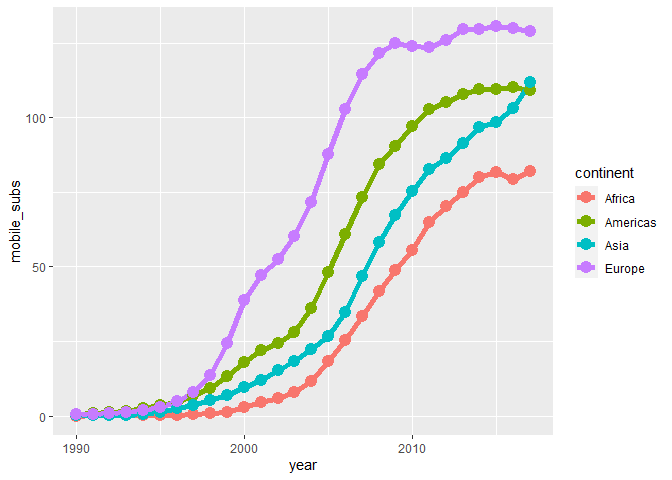

```r
phones %>%
  group_by(year, continent) %>%
  summarize(mobile_subs = mean(mobile_subs, na.rm = TRUE)) %>%
  ggplot(aes(year, mobile_subs, color = continent)) +
  geom_line(size = 2) +
  geom_point(size = 4)
```